# The Effects of Trip Data Characteristics on Their Duration

## Investigation Overview

In this investigation

- I want to show the trip in a relation with weekdays and months.
- I will show the pie chart for user types in the trip
- I will show the distribution of the age in a relation with the duration of the trip
- I will show if Bike sharing has effect on the duration of the trip or not.
- I will show if the user type has effect on the duration according to weekdays of the trip.

## Dataset Overview

The dataset with 174952 and 22 features (duration_sec, start_time, end_time, start_station_id, start_station_name, start_station_latitude, start_station_longitude, end_station_id, end_station_name, end_station_latitude,end_station_longitude, bike_id, user_type, member_birth_year, member_gender, bike_share_for_all_trip,start_date,start_day,start_month,start_year,duration_min,member_age). Most variables are 11 numerical, and others are 1 datetime, 10 object type after preprocessing.

## Visualize the weekdays and months for the trip

I will show which day is the most frequent for the trip.

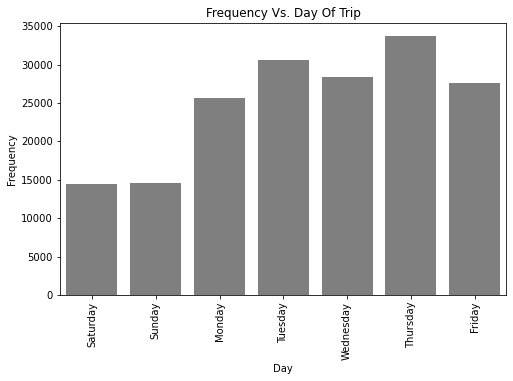

Well As we can notice:

- the most frequent day of all trips is Thursday

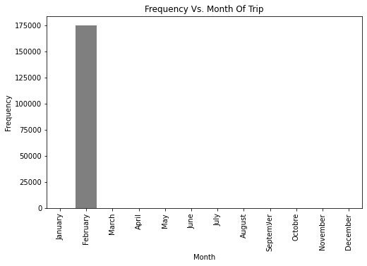

## Visualize The Distribution of Users and Trip Durations

Visualize the percentage of Both two user types(Customers and Subscribers)

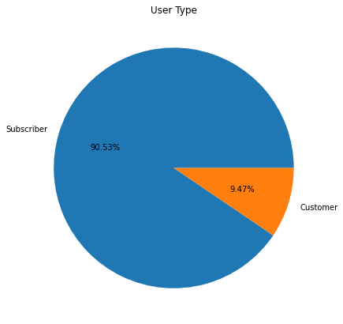

## Visualize The Histogram of Age

We can notice that the distribution is centered at the range 20 and 45 (Young users).

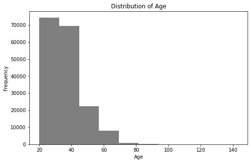

## Visualize The Distribution Between Trip Duration and Age

The most frequent users aged in the range 20 and 45 have higher duration in the trip.

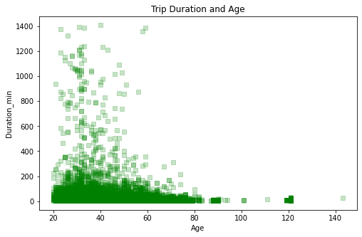

## Visualize Trip Duration and bike_share_for_all_trip

The users who do not make bike_share_for_all_trip takes little higher duration than who make bike_share_for_all_trip .

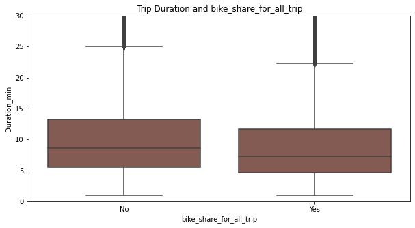

## Visualize Trip Duration and Day of Week by User type

- The customers have large duration trip within days than the subscribers
- The Subscribers are almost consistent through all weekdays

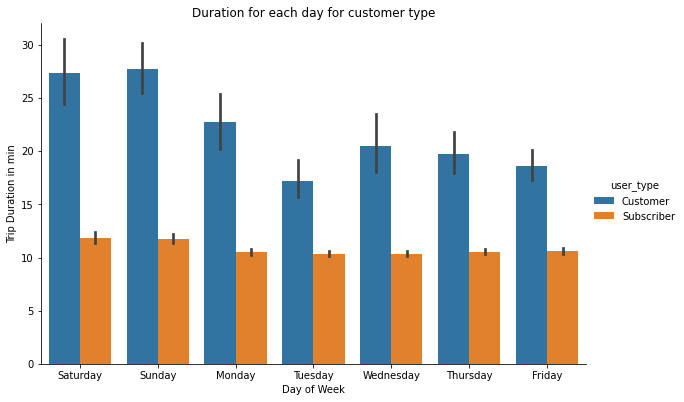